# act_report-Copy1

## Analysis and Insights of the Dogs on the Net

The numbers don’t lie: Dogs are the internet’s favorite animal(source: https://theoutline.com/post/3128/dogs-cats-internet-popularity?zd=1&zi=m3fy472z)

This headline from theoutline shows the dominant position taken by dogs in the internet space. There are many changes about the information about man's best friend, the dog. Everyday, a new viral picture, .gif, or video of a dog arrives in my social feed and on the front page of our favorite websites. The dictionaries have added new vocabulary about the dogs names like doggo,puppo etc. Google infact tells that 2018 is the year of the dog. Dogs are having moment online. This, of course, is good. We have analysed the data about the dogs and found the following insights. Dogs have captured the internet space with a bang. Compared to cats dogs have more ownership in America.Searches for dogs have exceed that of cats. We have summarized the following insights about the tweets from twitter.

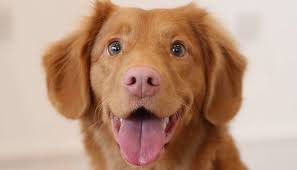

# Insight 1: Most common dog

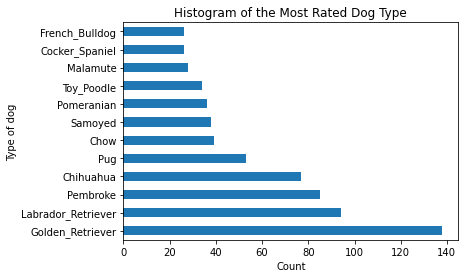

I have analysed data on the basis of the first predictions and found the following:

Golden Retriever is the most popular breed, Followed by Labrador Retriever.

These dogs have the most tweets and which leads them to most popular breed.

# Insight 2: Relationship between ratings and retweet counts

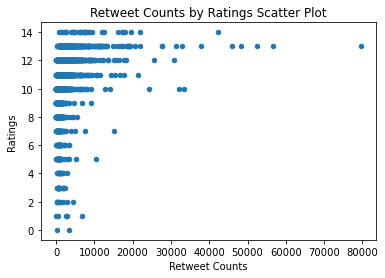

As you can see above as the Retweet counts increases the Ratings also increases

# Insight 3: Retweets and favorites

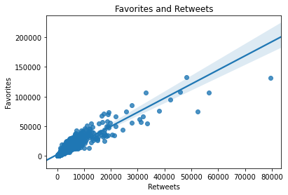

There is a positive relationship between retweets and favorites As tweets increase so the favorites increase and so the retweets also increase.

# Other Observations:

1. Charlie is most common name. Followed by lucy cooper.
1. Most of the tweets are sent through iphone. Around 98% of twitter users commenting on dogsare using iPhone